# Project: Investigating tmdb-movies.csv file Dataset

- Introduction
- Data Wrangling
- Exploratory Data Analysis
- Conclusions
- Limitations

## Introduction

> In this project, we would be investigating a movie dataset covering a study period. This data set contains information about 10,000 movies collected from The Movie Database (TMDb), including user ratings and revenue. Certain columns, like ‘cast’ and ‘genres’, contain multiple values separated by pipe (|) characters. There are some odd characters in the ‘cast’ column. The final two columns ending with “_adj” show the budget and revenue of the associated movie in terms of 2010 dollars, accounting for inflation over time.

### Research Question 1 (Budget,Revenue, Budget_adj and Revenue_adj)

### Research Question 2 (What kind of properties are associated with movies that have high revenues?(Popularity, budget and runtime))

### Research Question 3 (What is the relationship between Runtime and Popularity)

### Research Question 4 (Which genres are most popular from year to year? )

Loading packages to be used for our analysis in the next line of codes:

```python
import numpy as np
import pandas as pd
import matplotlib.pyplot as plt
import seaborn as sns

%matplotlib inline
```

## General Properties

In this section of the report, we will load in the data using the pandas library, check for cleanliness if need be, and then trim and clean our dataset for analysis.

Using pandas library to read the tmdb-movies.csv file

```python
df_moviedata = pd.read_csv("Database_TMDb_movie_data/tmdb-movies.csv")
```

let's have sneak peek of our imported movie dataset

```python
df_moviedata.head()
```

|  | id | imdb_id | popularity | budget | revenue | original_title | cast | homepage | director | tagline | ... | overview | runtime | genres | production_companies | release_date | vote_count | vote_average | release_year | budget_adj | revenue_adj |
| --- | --- | --- | --- | --- | --- | --- | --- | --- | --- | --- | --- | --- | --- | --- | --- | --- | --- | --- | --- | --- | --- |
| 0 | 135397 | tt0369610 | 32.985763 | 150000000 | 1513528810 | Jurassic World | Chris Pratt\|Bryce Dallas Howard\|Irrfan Khan\|Vi... | http://www.jurassicworld.com/ | Colin Trevorrow | The park is open. | ... | Twenty-two years after the events of Jurassic ... | 124 | Action\|Adventure\|Science Fiction\|Thriller | Universal Studios\|Amblin Entertainment\|Legenda... | 6/9/15 | 5562 | 6.5 | 2015 | 1.379999e+08 | 1.392446e+09 |
| 1 | 76341 | tt1392190 | 28.419936 | 150000000 | 378436354 | Mad Max: Fury Road | Tom Hardy\|Charlize Theron\|Hugh Keays-Byrne\|Nic... | http://www.madmaxmovie.com/ | George Miller | What a Lovely Day. | ... | An apocalyptic story set in the furthest reach... | 120 | Action\|Adventure\|Science Fiction\|Thriller | Village Roadshow Pictures\|Kennedy Miller Produ... | 5/13/15 | 6185 | 7.1 | 2015 | 1.379999e+08 | 3.481613e+08 |
| 2 | 262500 | tt2908446 | 13.112507 | 110000000 | 295238201 | Insurgent | Shailene Woodley\|Theo James\|Kate Winslet\|Ansel... | http://www.thedivergentseries.movie/#insurgent | Robert Schwentke | One Choice Can Destroy You | ... | Beatrice Prior must confront her inner demons ... | 119 | Adventure\|Science Fiction\|Thriller | Summit Entertainment\|Mandeville Films\|Red Wago... | 3/18/15 | 2480 | 6.3 | 2015 | 1.012000e+08 | 2.716190e+08 |
| 3 | 140607 | tt2488496 | 11.173104 | 200000000 | 2068178225 | Star Wars: The Force Awakens | Harrison Ford\|Mark Hamill\|Carrie Fisher\|Adam D... | http://www.starwars.com/films/star-wars-episod... | J.J. Abrams | Every generation has a story. | ... | Thirty years after defeating the Galactic Empi... | 136 | Action\|Adventure\|Science Fiction\|Fantasy | Lucasfilm\|Truenorth Productions\|Bad Robot | 12/15/15 | 5292 | 7.5 | 2015 | 1.839999e+08 | 1.902723e+09 |
| 4 | 168259 | tt2820852 | 9.335014 | 190000000 | 1506249360 | Furious 7 | Vin Diesel\|Paul Walker\|Jason Statham\|Michelle ... | http://www.furious7.com/ | James Wan | Vengeance Hits Home | ... | Deckard Shaw seeks revenge against Dominic Tor... | 137 | Action\|Crime\|Thriller | Universal Pictures\|Original Film\|Media Rights ... | 4/1/15 | 2947 | 7.3 | 2015 | 1.747999e+08 | 1.385749e+09 |

5 rows × 21 columns

let's take a look at the shape our movie dataset we would be investigating.

```python
df_moviedata.shape
```

```
(10866, 21)
```

We could see from the above result there are 10866 rows and 21 columns in total, Lets proceed to checking the dataset info to give us insight of the data-set in the csv file so as to enable us make a proper data wrangling technique to use.

```python
df_moviedata.describe()
```

|  | id | popularity | budget | revenue | runtime | vote_count | vote_average | release_year | budget_adj | revenue_adj |
| --- | --- | --- | --- | --- | --- | --- | --- | --- | --- | --- |
| count | 10866.000000 | 10866.000000 | 1.086600e+04 | 1.086600e+04 | 10866.000000 | 10866.000000 | 10866.000000 | 10866.000000 | 1.086600e+04 | 1.086600e+04 |
| mean | 66064.177434 | 0.646441 | 1.462570e+07 | 3.982332e+07 | 102.070863 | 217.389748 | 5.974922 | 2001.322658 | 1.755104e+07 | 5.136436e+07 |
| std | 92130.136561 | 1.000185 | 3.091321e+07 | 1.170035e+08 | 31.381405 | 575.619058 | 0.935142 | 12.812941 | 3.430616e+07 | 1.446325e+08 |
| min | 5.000000 | 0.000065 | 0.000000e+00 | 0.000000e+00 | 0.000000 | 10.000000 | 1.500000 | 1960.000000 | 0.000000e+00 | 0.000000e+00 |
| 25% | 10596.250000 | 0.207583 | 0.000000e+00 | 0.000000e+00 | 90.000000 | 17.000000 | 5.400000 | 1995.000000 | 0.000000e+00 | 0.000000e+00 |
| 50% | 20669.000000 | 0.383856 | 0.000000e+00 | 0.000000e+00 | 99.000000 | 38.000000 | 6.000000 | 2006.000000 | 0.000000e+00 | 0.000000e+00 |
| 75% | 75610.000000 | 0.713817 | 1.500000e+07 | 2.400000e+07 | 111.000000 | 145.750000 | 6.600000 | 2011.000000 | 2.085325e+07 | 3.369710e+07 |
| max | 417859.000000 | 32.985763 | 4.250000e+08 | 2.781506e+09 | 900.000000 | 9767.000000 | 9.200000 | 2015.000000 | 4.250000e+08 | 2.827124e+09 |

```python
#checking info
df_moviedata.info()
```

```
<class 'pandas.core.frame.DataFrame'>
RangeIndex: 10866 entries, 0 to 10865
Data columns (total 21 columns):
id                      10866 non-null int64
imdb_id                 10856 non-null object
popularity              10866 non-null float64
budget                  10866 non-null int64
revenue                 10866 non-null int64
original_title          10866 non-null object
cast                    10790 non-null object
homepage                2936 non-null object
director                10822 non-null object
tagline                 8042 non-null object
keywords                9373 non-null object
overview                10862 non-null object
runtime                 10866 non-null int64
genres                  10843 non-null object
production_companies    9836 non-null object
release_date            10866 non-null object
vote_count              10866 non-null int64
vote_average            10866 non-null float64
release_year            10866 non-null int64
budget_adj              10866 non-null float64
revenue_adj             10866 non-null float64
dtypes: float64(4), int64(6), object(11)
memory usage: 1.7+ MB
```

> The above output shows there exist empty cells within the datasets as the column data values count are not all tallying to the expected 10,866. Using **HOMEPAGE** as an example with 2936, which means there is 7930 empty cell existing in the column. We also can see there is mis-matched date type for release_date.

```python
#confirming the missing data in homepage series
df_moviedata.homepage.isnull().sum()
```

```
7930
```

As ascertained of existance of empty cells in our dataset, we would need to take this into account in our data cleaning phase.The total empty cells count for each feature is shown below.

```python
df_moviedata.isnull().sum()
```

```
id                         0
imdb_id                   10
popularity                 0
budget                     0
revenue                    0
original_title             0
cast                      76
homepage                7930
director                  44
tagline                 2824
keywords                1493
overview                   4
runtime                    0
genres                    23
production_companies    1030
release_date               0
vote_count                 0
vote_average               0
release_year               0
budget_adj                 0
revenue_adj                0
dtype: int64
```

Let's confirm if there exist a duplicate entry.

```python
df_moviedata.duplicated().sum()
```

```
1
```

We can see from the above output there exist a duplicate entry which would be taken care of in our cleaning stage. Let's view the total years of movie dataset investigation in our next code.

```python
df_moviedata.release_year.nunique()
```

```
56
```

we have 56 years of study period as shown output cell above. Let's view study samples per year in our next code.

```python
df_moviedata.groupby("release_year")["release_date"].nunique()
```

```
release_year
1960     31
1961     27
1962     30
1963     28
1964     39
1965     31
1966     40
1967     38
1968     33
1969     28
1970     38
1971     49
1972     35
1973     50
```

[output cut: 43 more lines]

## Data Wrangling

Since we have been able establish there exist null and duplicate cells in our movie dataset. Hence, we need to perform a clean up operation to ensure efficiency of our analysis.To perform this clean up, we would be dropping columns with empty cells **imdb_id,cast,homepage,director,tagline,keywords,overview,production_companies** as they don't really make impact in our analysis, except for **Genre** which would be excluded.

```python
# Removes all columns between column index 1,6 to 11 and 14
col_index = np.r_[1,6:12,14]
df_moviedata.drop(df_moviedata.iloc[:,col_index], inplace=True, axis = 1)
```

let's confirm in our code below if that's been established.

```python
df_moviedata.head()
```

|  | id | popularity | budget | revenue | original_title | runtime | genres | release_date | vote_count | vote_average | release_year | budget_adj | revenue_adj |
| --- | --- | --- | --- | --- | --- | --- | --- | --- | --- | --- | --- | --- | --- |
| 0 | 135397 | 32.985763 | 150000000 | 1513528810 | Jurassic World | 124 | Action\|Adventure\|Science Fiction\|Thriller | 6/9/15 | 5562 | 6.5 | 2015 | 1.379999e+08 | 1.392446e+09 |
| 1 | 76341 | 28.419936 | 150000000 | 378436354 | Mad Max: Fury Road | 120 | Action\|Adventure\|Science Fiction\|Thriller | 5/13/15 | 6185 | 7.1 | 2015 | 1.379999e+08 | 3.481613e+08 |
| 2 | 262500 | 13.112507 | 110000000 | 295238201 | Insurgent | 119 | Adventure\|Science Fiction\|Thriller | 3/18/15 | 2480 | 6.3 | 2015 | 1.012000e+08 | 2.716190e+08 |
| 3 | 140607 | 11.173104 | 200000000 | 2068178225 | Star Wars: The Force Awakens | 136 | Action\|Adventure\|Science Fiction\|Fantasy | 12/15/15 | 5292 | 7.5 | 2015 | 1.839999e+08 | 1.902723e+09 |
| 4 | 168259 | 9.335014 | 190000000 | 1506249360 | Furious 7 | 137 | Action\|Crime\|Thriller | 4/1/15 | 2947 | 7.3 | 2015 | 1.747999e+08 | 1.385749e+09 |

Let's confirm the empty cells again in our edited dataset using our next line of code below.

```python
df_moviedata.isna().sum()
```

```
id                 0
popularity         0
budget             0
revenue            0
original_title     0
runtime            0
genres            23
release_date       0
vote_count         0
vote_average       0
release_year       0
budget_adj         0
revenue_adj        0
dtype: int64
```

> As earlier stated, we excluded the **Genre** from our dropped column as it forms the basis of one our research question. We have 23 cells missing in our **Genre** feature. We can drop the rows with empty cells now to obtain our refined dataset.

```python
#dropping the empty cells rows
df_moviedata.dropna(inplace=True)
```

Let's now confirm if our data is all good.

```python
df_moviedata.isna().sum()
```

```
id                0
popularity        0
budget            0
revenue           0
original_title    0
runtime           0
genres            0
release_date      0
vote_count        0
vote_average      0
release_year      0
budget_adj        0
revenue_adj       0
dtype: int64
```

As shown from the above result, the final need to is dropping duplicated entry and changing release_date data types, afterwhich we all good and marks the end of our clean up.

```python
# drops duplicate cells
df_moviedata.drop_duplicates(inplace=True)
```

let's confirm.

```python
df_moviedata.duplicated().sum()
```

```
0
```

```python
# changing type to datetime
df_moviedata.release_date = pd.to_datetime(df_moviedata.release_date, utc=True)
```

We all good now, let's preview our cleaned dataset to see what we would be working with.

```python
df_moviedata.dtypes
```

```
id                              int64
popularity                    float64
budget                          int64
revenue                         int64
original_title                 object
runtime                         int64
genres                         object
release_date      datetime64[ns, UTC]
vote_count                      int64
vote_average                  float64
release_year                    int64
budget_adj                    float64
revenue_adj                   float64
dtype: object
```

```python
df_moviedata.head()
```

|  | id | popularity | budget | revenue | original_title | runtime | genres | release_date | vote_count | vote_average | release_year | budget_adj | revenue_adj |
| --- | --- | --- | --- | --- | --- | --- | --- | --- | --- | --- | --- | --- | --- |
| 0 | 135397 | 32.985763 | 150000000 | 1513528810 | Jurassic World | 124 | Action\|Adventure\|Science Fiction\|Thriller | 2015-06-09 00:00:00+00:00 | 5562 | 6.5 | 2015 | 1.379999e+08 | 1.392446e+09 |
| 1 | 76341 | 28.419936 | 150000000 | 378436354 | Mad Max: Fury Road | 120 | Action\|Adventure\|Science Fiction\|Thriller | 2015-05-13 00:00:00+00:00 | 6185 | 7.1 | 2015 | 1.379999e+08 | 3.481613e+08 |
| 2 | 262500 | 13.112507 | 110000000 | 295238201 | Insurgent | 119 | Adventure\|Science Fiction\|Thriller | 2015-03-18 00:00:00+00:00 | 2480 | 6.3 | 2015 | 1.012000e+08 | 2.716190e+08 |
| 3 | 140607 | 11.173104 | 200000000 | 2068178225 | Star Wars: The Force Awakens | 136 | Action\|Adventure\|Science Fiction\|Fantasy | 2015-12-15 00:00:00+00:00 | 5292 | 7.5 | 2015 | 1.839999e+08 | 1.902723e+09 |
| 4 | 168259 | 9.335014 | 190000000 | 1506249360 | Furious 7 | 137 | Action\|Crime\|Thriller | 2015-04-01 00:00:00+00:00 | 2947 | 7.3 | 2015 | 1.747999e+08 | 1.385749e+09 |

```python
df_moviedata.shape
```

```
(10842, 13)
```

As shown in the results above, we now have total of 10842 rows and 13 columns as against (10866, 21) we had prior to clean up. All are of equal lenght across the column. We now set to continue to our Exploratory analysis.

## Exploratory Data Analysis

We're ready to move on to exploration. Compute statistics and create visualizations with the goal of addressing the research questions that we be investigating in the subsequent section.

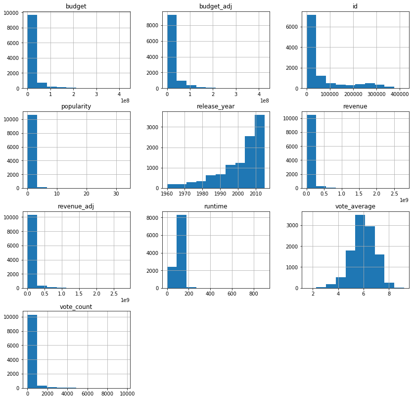

```python
df_moviedata.hist(figsize=(14,14));
```

The distribution of the release_year is skewed to the left and vote_average having almost a normal distribution as seen in the histogram matrix output above.

### Research Question 1 (What is the pattern in Budget and Budget_adj, Revenue and Revenue_adj?)

> We would be using a line graph to identify this question.

```python
# data to be plotted in the line graph
df_moviedata.groupby(['release_year'])["budget",'budget_adj'].mean()
```

| release_year | budget | budget_adj |
| --- | --- | --- |
| 1960 | 6.892796e+05 | 5.082036e+06 |
| 1961 | 1.488290e+06 | 1.085687e+07 |
| 1962 | 1.710066e+06 | 1.232693e+07 |
| 1963 | 2.156809e+06 | 1.535687e+07 |
| 1964 | 9.400753e+05 | 6.608980e+06 |
| 1965 | 2.005860e+06 | 1.388168e+07 |
| 1966 | 1.251191e+06 | 8.405522e+06 |
| 1967 | 2.516305e+06 | 1.644849e+07 |
| 1968 | 1.844590e+06 | 1.156367e+07 |
| 1969 | 1.359003e+06 | 8.078272e+06 |
| 1970 | 3.174049e+06 | 1.782663e+07 |
| 1971 | 1.381764e+06 | 7.441067e+06 |
| 1972 | 9.069813e+05 | 4.729510e+06 |
| 1973 | 1.185287e+06 | 5.821133e+06 |
| 1974 | 1.673261e+06 | 7.399635e+06 |
| 1975 | 1.279068e+06 | 5.182556e+06 |
| 1976 | 2.598936e+06 | 9.958339e+06 |
| 1977 | 2.834737e+06 | 1.019876e+07 |
| 1978 | 3.215339e+06 | 1.074791e+07 |
| 1979 | 4.470421e+06 | 1.343162e+07 |
| 1980 | 4.647436e+06 | 1.229729e+07 |
| 1981 | 4.558022e+06 | 1.093101e+07 |
| 1982 | 5.404877e+06 | 1.221309e+07 |
| 1983 | 6.488843e+06 | 1.420610e+07 |
| 1984 | 6.944876e+06 | 1.457759e+07 |
| 1985 | 6.868997e+06 | 1.392460e+07 |
| 1986 | 5.822592e+06 | 1.158350e+07 |
| 1987 | 5.675646e+06 | 1.089202e+07 |
| 1988 | 6.381710e+06 | 1.176718e+07 |
| 1989 | 7.938650e+06 | 1.396397e+07 |
| 1990 | 9.772137e+06 | 1.630870e+07 |
| 1991 | 1.102431e+07 | 1.765094e+07 |
| 1992 | 1.084034e+07 | 1.684615e+07 |
| 1993 | 9.997914e+06 | 1.509155e+07 |
| 1994 | 1.211526e+07 | 1.782289e+07 |
| 1995 | 1.647060e+07 | 2.356888e+07 |
| 1996 | 1.816277e+07 | 2.525019e+07 |
| 1997 | 2.474524e+07 | 3.361543e+07 |
| 1998 | 2.142695e+07 | 2.866274e+07 |
| 1999 | 2.573766e+07 | 3.369195e+07 |
| 2000 | 2.545442e+07 | 3.223274e+07 |
| 2001 | 2.341056e+07 | 2.882982e+07 |
| 2002 | 2.216030e+07 | 2.686408e+07 |
| 2003 | 2.220590e+07 | 2.632182e+07 |
| 2004 | 2.335616e+07 | 2.696341e+07 |
| 2005 | 2.022943e+07 | 2.258744e+07 |
| 2006 | 1.790732e+07 | 1.936979e+07 |
| 2007 | 1.743281e+07 | 1.833353e+07 |
| 2008 | 1.571972e+07 | 1.592072e+07 |
| 2009 | 1.618472e+07 | 1.645015e+07 |
| 2010 | 1.920945e+07 | 1.920945e+07 |
| 2011 | 1.670028e+07 | 1.618922e+07 |
| 2012 | 1.416795e+07 | 1.345593e+07 |
| 2013 | 1.407933e+07 | 1.317872e+07 |
| 2014 | 1.133618e+07 | 1.044165e+07 |
| 2015 | 1.211571e+07 | 1.114644e+07 |

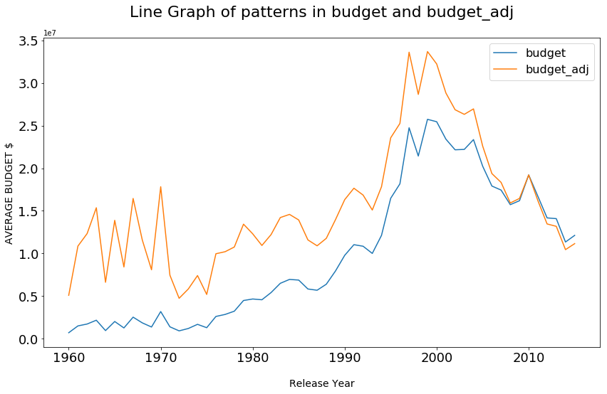

```python
# function to plot average graph pattern corresponding to budget and revenue
def plotavg(x):
    '''
    Plotting the pattern of average revenue and revenue_adj, budget and budget_adj using line graph grouped by year.

    '''
    #plotting graph
    ax = df_moviedata.groupby("release_year")[[x,x + "_adj"]].mean().plot(kind="line", figsize=(14,8),fontsize=18)
    ax.set_title("Line Graph of patterns in {} and {}\n".format(x,x +"_adj"),fontsize=22)
    ax.set_xlabel("\nRelease Year",fontsize=14);
    ax.set_ylabel("AVERAGE "+ str.upper(x) + ' $',fontsize=14);
    ax.legend(fontsize=16)

if __name__ =="__main__":
    plotavg("budget")
```

```python
# data to be plotted for revenue
df_moviedata.groupby(['release_year'])["revenue",'revenue_adj'].mean()
```

| release_year | revenue | revenue_adj |
| --- | --- | --- |
| 1960 | 4.531406e+06 | 3.340991e+07 |
| 1961 | 1.089420e+07 | 7.947167e+07 |
| 1962 | 6.736870e+06 | 4.856238e+07 |
| 1963 | 5.511911e+06 | 3.924580e+07 |
| 1964 | 8.118614e+06 | 5.707603e+07 |
| 1965 | 1.308805e+07 | 9.057670e+07 |
| 1966 | 1.842102e+06 | 1.237527e+07 |
| 1967 | 1.844587e+07 | 1.205763e+08 |
| 1968 | 6.788025e+06 | 4.255388e+07 |
| 1969 | 7.869583e+06 | 4.677888e+07 |
| 1970 | 1.400555e+07 | 7.866032e+07 |
| 1971 | 7.362011e+06 | 3.964586e+07 |
| 1972 | 1.236825e+07 | 6.449502e+07 |
| 1973 | 2.225420e+07 | 1.092939e+08 |
| 1974 | 1.766391e+07 | 7.811482e+07 |
| 1975 | 2.176114e+07 | 8.817223e+07 |
| 1976 | 1.704267e+07 | 6.530237e+07 |
| 1977 | 3.825584e+07 | 1.376362e+08 |
| 1978 | 2.107353e+07 | 7.044251e+07 |
| 1979 | 2.955781e+07 | 8.880802e+07 |
| 1980 | 2.267516e+07 | 5.999930e+07 |
| 1981 | 2.164154e+07 | 5.190054e+07 |
| 1982 | 3.035116e+07 | 6.858277e+07 |
| 1983 | 2.884412e+07 | 6.314877e+07 |
| 1984 | 2.510023e+07 | 5.268644e+07 |
| 1985 | 2.638323e+07 | 5.348319e+07 |
| 1986 | 2.481635e+07 | 4.936980e+07 |
| 1987 | 2.769684e+07 | 5.315246e+07 |
| 1988 | 2.579001e+07 | 4.755396e+07 |
| 1989 | 3.797738e+07 | 6.680164e+07 |
| 1990 | 4.026641e+07 | 6.720056e+07 |
| 1991 | 3.538797e+07 | 5.665942e+07 |
| 1992 | 4.570040e+07 | 7.101953e+07 |
| 1993 | 3.907388e+07 | 5.898085e+07 |
| 1994 | 3.856212e+07 | 5.672917e+07 |
| 1995 | 5.262265e+07 | 7.530127e+07 |
| 1996 | 4.094331e+07 | 5.692008e+07 |
| 1997 | 5.549569e+07 | 7.538870e+07 |
| 1998 | 4.520559e+07 | 6.047132e+07 |
| 1999 | 5.069515e+07 | 6.636262e+07 |
| 2000 | 4.857832e+07 | 6.151435e+07 |
| 2001 | 5.564350e+07 | 6.852431e+07 |
| 2002 | 5.505120e+07 | 6.673644e+07 |
| 2003 | 5.387275e+07 | 6.385821e+07 |
| 2004 | 5.470301e+07 | 6.315163e+07 |
| 2005 | 4.550092e+07 | 5.080466e+07 |
| 2006 | 3.989152e+07 | 4.314942e+07 |
| 2007 | 4.431888e+07 | 4.660877e+07 |
| 2008 | 3.925595e+07 | 3.975790e+07 |
| 2009 | 4.177057e+07 | 4.245562e+07 |
| 2010 | 4.509041e+07 | 4.509041e+07 |
| 2011 | 4.388073e+07 | 4.253789e+07 |
| 2012 | 4.224046e+07 | 4.011764e+07 |
| 2013 | 3.765798e+07 | 3.524912e+07 |
| 2014 | 3.480851e+07 | 3.206181e+07 |
| 2015 | 4.268333e+07 | 3.926865e+07 |

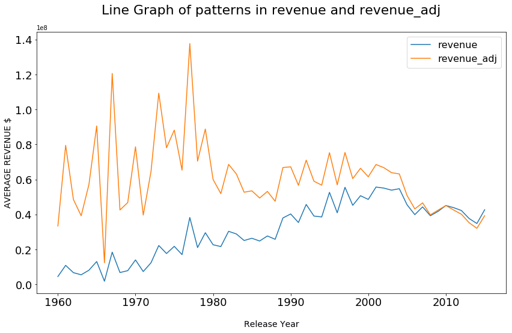

```python
#Plotting for revenue
plotavg("revenue")
```

### Research Question 2 (What kinds of properties are associated with movies that have high revenues?(Popularity, budget and runtime)

> We would be using a scatter plot to test the relationship between these properties in our subsequent code.

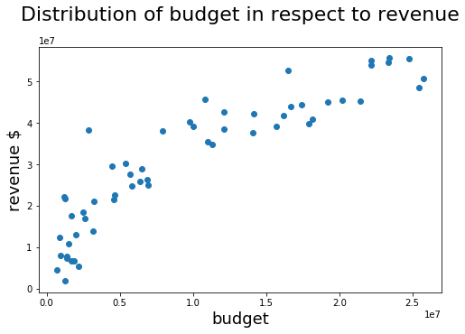

```python
# Revenue against popularity.

df_prop = pd.DataFrame(df_moviedata.groupby(['release_year'])[['revenue','budget','popularity','runtime']].mean())

def Rplot(a,b):
    '''
    Plot to see the relationship between the most common features that influences a movie in respect to revenue.
    '''
    plt.figure(figsize=(8,5))
    plt.scatter(x=df_prop[a],y=df_prop[b]);
    plt.xlabel(a,fontsize=18)
    if b == 'revenue':
        plt.ylabel(b + ' $',fontsize=18)
    else:
        plt.ylabel(b,fontsize=18)
    plt.title(f"Distribution of {a} in respect to {b}\n",fontsize=22);



if __name__ == "__main__":
    Rplot('budget','revenue')
```

As shown in the figure above, there exist a positive non-linear correlation between budget and revenue. Implication of this simply means, the higher the budget, the higher the revenue and vice versa.

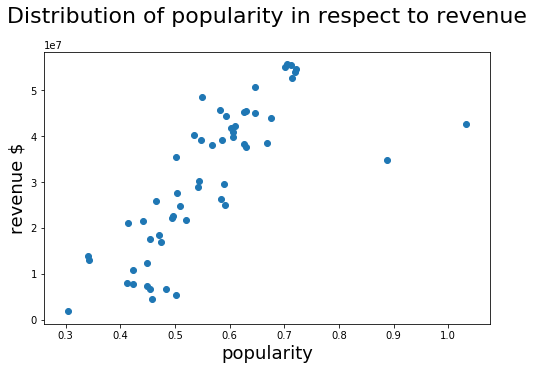

```python
Rplot("popularity",'revenue')
```

There also exist a positive correlation as shown in the above output, which implies that, the higher the popularity, the higher the revenue and vice versa as calculated using average popularity and revenue obtained from the study set.

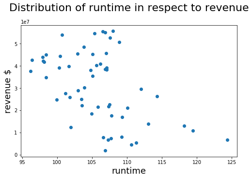

```python
Rplot("runtime","revenue")
```

### Research Question 3 (What is the relationship between Runtime and Popularity?)

> Scatter plot would be used in our next line of code to check for the relationship between runtime and popularity using the function previously created. i.e Rplot()

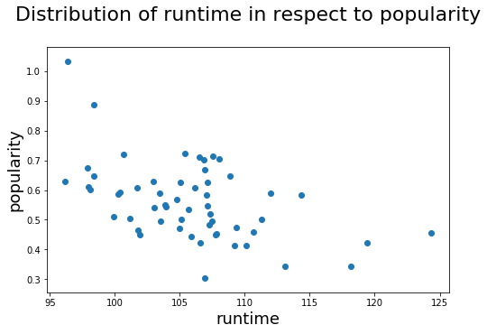

```python
Rplot("runtime","popularity")
```

> we observe that, there exist a weak negative relationship between runtime and popularity. Which further drives our point previously on checking the relationship between runtime and revenue. Popularity and revenue was observed to have positive correlation, and now we could see from the result above runtime is inversely proportional to popularity.

### Research Question 4 (Which genres are most popular from year to year? )

> We would need to sort of genres and popularity columns as would be demonstrated in our subsequent codes below.

```python
# filtering out features peculiar to answering question 4.
df_genre = df_moviedata.filter(items=['release_year','genres','popularity'])
df_genre
```

|  | release_year | genres | popularity |
| --- | --- | --- | --- |
| 0 | 2015 | Action\|Adventure\|Science Fiction\|Thriller | 32.985763 |
| 1 | 2015 | Action\|Adventure\|Science Fiction\|Thriller | 28.419936 |
| 2 | 2015 | Adventure\|Science Fiction\|Thriller | 13.112507 |
| 3 | 2015 | Action\|Adventure\|Science Fiction\|Fantasy | 11.173104 |
| 4 | 2015 | Action\|Crime\|Thriller | 9.335014 |
| 5 | 2015 | Western\|Drama\|Adventure\|Thriller | 9.110700 |
| 6 | 2015 | Science Fiction\|Action\|Thriller\|Adventure | 8.654359 |
| 7 | 2015 | Drama\|Adventure\|Science Fiction | 7.667400 |
| 8 | 2015 | Family\|Animation\|Adventure\|Comedy | 7.404165 |
| 9 | 2015 | Comedy\|Animation\|Family | 6.326804 |
| 10 | 2015 | Action\|Adventure\|Crime | 6.200282 |
| 11 | 2015 | Science Fiction\|Fantasy\|Action\|Adventure | 6.189369 |
| 12 | 2015 | Drama\|Science Fiction | 6.118847 |
| 13 | 2015 | Action\|Comedy\|Science Fiction | 5.984995 |
| 14 | 2015 | Action\|Adventure\|Science Fiction | 5.944927 |
| 15 | 2015 | Crime\|Drama\|Mystery\|Western | 5.898400 |
| 16 | 2015 | Crime\|Action\|Thriller | 5.749758 |
| 17 | 2015 | Science Fiction\|Action\|Adventure | 5.573184 |
| 18 | 2015 | Romance\|Fantasy\|Family\|Drama | 5.556818 |
| 19 | 2015 | War\|Adventure\|Science Fiction | 5.476958 |
| 20 | 2015 | Action\|Family\|Science Fiction\|Adventure\|Mystery | 5.462138 |
| 21 | 2015 | Action\|Drama | 5.337064 |
| 22 | 2015 | Action\|Drama\|Thriller | 4.907832 |
| 23 | 2015 | Drama\|Romance | 4.710402 |
| 24 | 2015 | Comedy\|Drama | 4.648046 |
| 25 | 2015 | Action | 4.566713 |
| 26 | 2015 | Comedy | 4.564549 |
| 27 | 2015 | Crime\|Comedy\|Action\|Adventure | 4.503789 |
| 28 | 2015 | Drama\|Thriller\|History | 4.062293 |
| 29 | 2015 | Action\|Science Fiction\|Thriller | 3.968891 |
| ... | ... | ... | ... |
| 10836 | 1966 | Comedy\|Romance | 0.239435 |
| 10837 | 1966 | War\|Action\|Adventure\|Drama | 0.291704 |
| 10838 | 1966 | Action\|Adventure\|Western | 0.151845 |
| 10839 | 1966 | Family\|Animation | 0.276133 |
| 10840 | 1966 | Thriller | 0.102530 |
| 10841 | 1966 | Western | 0.264925 |
| 10842 | 1966 | Animation\|Family | 0.253437 |
| 10843 | 1966 | Adventure\|Drama\|War\|History\|Action | 0.252399 |
| 10844 | 1966 | Adventure\|Comedy\|Fantasy\|Science Fiction | 0.236098 |
| 10845 | 1966 | Comedy\|Western | 0.230873 |
| 10846 | 1966 | Horror | 0.212716 |
| 10847 | 1966 | Science Fiction\|Horror | 0.034555 |
| 10848 | 1966 | Adventure\|Science Fiction | 0.207257 |
| 10849 | 1966 | Action\|Comedy\|Crime | 0.206537 |
| 10850 | 1966 | Action\|Drama\|Thriller\|Crime\|Mystery | 0.202473 |
| 10851 | 1966 | Adventure\|Drama\|Action\|Family\|Foreign | 0.342791 |
| 10852 | 1966 | Western | 0.227220 |
| 10853 | 1966 | Comedy\|Drama\|Romance | 0.163592 |
| 10854 | 1966 | Thriller\|Drama\|Crime | 0.146402 |
| 10855 | 1966 | Comedy\|Family\|Mystery\|Romance | 0.141026 |
| 10856 | 1966 | Comedy\|Drama\|Family | 0.140934 |
| 10857 | 1966 | Action\|Western | 0.131378 |
| 10858 | 1966 | Comedy\|War | 0.317824 |
| 10859 | 1966 | Mystery\|Science Fiction\|Thriller\|Drama | 0.089072 |
| 10860 | 1966 | Comedy | 0.087034 |
| 10861 | 1966 | Documentary | 0.080598 |
| 10862 | 1966 | Action\|Adventure\|Drama | 0.065543 |
| 10863 | 1966 | Mystery\|Comedy | 0.065141 |
| 10864 | 1966 | Action\|Comedy | 0.064317 |
| 10865 | 1966 | Horror | 0.035919 |

10842 rows × 3 columns

```python
#  Extracting maximum genres per year
df_genres_max = pd.DataFrame(df_genre.groupby("release_year")['popularity'].max())
df_genres_max
```

| release_year | popularity |
| --- | --- |
| 1960 | 2.610362 |
| 1961 | 2.631987 |
| 1962 | 3.170651 |
| 1963 | 2.508235 |
| 1964 | 3.153791 |
| 1965 | 1.910465 |
| 1966 | 1.227582 |
| 1967 | 2.550704 |
| 1968 | 3.309196 |
| 1969 | 1.778746 |
| 1970 | 1.936962 |
| 1971 | 3.072555 |
| 1972 | 5.738034 |
| 1973 | 2.272486 |
| 1974 | 3.264571 |
| 1975 | 3.258151 |
| 1976 | 2.582657 |
| 1977 | 12.037933 |
| 1978 | 1.697618 |
| 1979 | 4.935897 |
| 1980 | 5.488441 |
| 1981 | 4.578300 |
| 1982 | 4.215642 |
| 1983 | 4.828854 |
| 1984 | 4.831966 |
| 1985 | 6.095293 |
| 1986 | 2.485419 |
| 1987 | 3.474728 |
| 1988 | 3.777441 |
| 1989 | 4.143585 |
| 1990 | 2.679627 |
| 1991 | 3.852269 |
| 1992 | 4.586426 |
| 1993 | 2.571339 |
| 1994 | 8.093754 |
| 1995 | 4.765359 |
| 1996 | 4.480733 |
| 1997 | 6.668990 |
| 1998 | 4.180540 |
| 1999 | 8.947905 |
| 2000 | 4.271452 |
| 2001 | 8.575419 |
| 2002 | 8.095275 |
| 2003 | 7.122455 |
| 2004 | 5.827781 |
| 2005 | 5.939927 |
| 2006 | 5.838503 |
| 2007 | 4.965391 |
| 2008 | 8.466668 |
| 2009 | 9.432768 |
| 2010 | 9.363643 |
| 2011 | 8.411577 |
| 2012 | 7.637767 |
| 2013 | 6.112766 |
| 2014 | 24.949134 |
| 2015 | 32.985763 |

```python
#Filtering out the maximum popularity to equate to corresponding genres
PopularGenres = df_genres_max.merge(df_genre,left_on='popularity',right_on='popularity')[['release_year','genres','popularity']]
PopularGenres
```

|  | release_year | genres | popularity |
| --- | --- | --- | --- |
| 0 | 1960 | Drama\|Horror\|Thriller | 2.610362 |
| 1 | 1961 | Adventure\|Animation\|Comedy\|Family | 2.631987 |
| 2 | 1962 | Adventure\|Action\|Thriller | 3.170651 |
| 3 | 1963 | Action\|Thriller\|Adventure | 2.508235 |
| 4 | 1964 | Adventure\|Action\|Thriller | 3.153791 |
| 5 | 1965 | Adventure\|Action\|Thriller | 1.910465 |
| 6 | 1966 | Animation\|Family\|Comedy | 1.227582 |
| 7 | 1967 | Family\|Animation\|Adventure | 2.550704 |
| 8 | 1968 | Science Fiction\|Mystery\|Adventure | 3.309196 |
| 9 | 1969 | Adventure\|Action\|Thriller | 1.778746 |
| 10 | 1970 | Animation\|Comedy\|Family\|Adventure | 1.936962 |
| 11 | 1971 | Science Fiction\|Drama | 3.072555 |
| 12 | 1972 | Drama\|Crime | 5.738034 |
| 13 | 1973 | Animation\|Family | 2.272486 |
| 14 | 1974 | Drama\|Crime | 3.264571 |
| 15 | 1975 | Drama | 3.258151 |
| 16 | 1976 | Crime\|Drama | 2.582657 |
| 17 | 1977 | Adventure\|Action\|Science Fiction | 12.037933 |
| 18 | 1978 | Music | 1.697618 |
| 19 | 1979 | Horror\|Action\|Thriller\|Science Fiction | 4.935897 |
| 20 | 1980 | Adventure\|Action\|Science Fiction | 5.488441 |
| 21 | 1981 | Adventure\|Action | 4.578300 |
| 22 | 1982 | Science Fiction\|Drama\|Thriller | 4.215642 |
| 23 | 1983 | Adventure\|Action\|Science Fiction | 4.828854 |
| 24 | 1984 | Action\|Thriller\|Science Fiction | 4.831966 |
| 25 | 1985 | Adventure\|Comedy\|Science Fiction\|Family | 6.095293 |
| 26 | 1986 | Horror\|Action\|Thriller\|Science Fiction | 2.485419 |
| 27 | 1987 | Science Fiction\|Action\|Adventure\|Thriller | 3.474728 |
| 28 | 1988 | Action\|Thriller | 3.777441 |
| 29 | 1989 | Animation\|Family | 4.143585 |
| 30 | 1990 | Action\|Adventure\|Science Fiction | 2.679627 |
| 31 | 1991 | Romance\|Family\|Animation\|Fantasy\|Music | 3.852269 |
| 32 | 1992 | Crime\|Thriller | 4.586426 |
| 33 | 1993 | Romance\|Fantasy\|Drama\|Comedy | 2.571339 |
| 34 | 1994 | Thriller\|Crime | 8.093754 |
| 35 | 1995 | Crime\|Mystery\|Thriller | 4.765359 |
| 36 | 1996 | Action\|Adventure\|Science Fiction | 4.480733 |
| 37 | 1997 | Comedy | 6.668990 |
| 38 | 1998 | Comedy\|Drama | 4.180540 |
| 39 | 1999 | Drama | 8.947905 |
| 40 | 2000 | Action\|Drama\|Adventure | 4.271452 |
| 41 | 2001 | Adventure\|Fantasy\|Action | 8.575419 |
| 42 | 2002 | Adventure\|Fantasy\|Action | 8.095275 |
| 43 | 2003 | Adventure\|Fantasy\|Action | 7.122455 |
| 44 | 2004 | Adventure\|Fantasy\|Family | 5.827781 |
| 45 | 2005 | Adventure\|Fantasy\|Family | 5.939927 |
| 46 | 2006 | Fantasy\|Action\|Science Fiction\|Thriller | 5.838503 |
| 47 | 2007 | Adventure\|Fantasy\|Action | 4.965391 |
| 48 | 2008 | Drama\|Action\|Crime\|Thriller | 8.466668 |
| 49 | 2009 | Action\|Adventure\|Fantasy\|Science Fiction | 9.432768 |
| 50 | 2010 | Action\|Thriller\|Science Fiction\|Mystery\|Adventure | 9.363643 |
| 51 | 2011 | Action\|Animation\|Horror | 8.411577 |
| 52 | 2012 | Science Fiction\|Action\|Adventure | 7.637767 |
| 53 | 2013 | Animation\|Adventure\|Family | 6.112766 |
| 54 | 2014 | Adventure\|Drama\|Science Fiction | 24.949134 |
| 55 | 2015 | Action\|Adventure\|Science Fiction\|Thriller | 32.985763 |

> The above output shows the most populous genres by years covering the study period of 1960 to 2015 of our movie dataset.

## Conclusions

> Nothing is constant and change is inevitable as shown by our line graph of budget and budget_adj, likewise revenue and revenue_adj. There exists irregularities from 1960 to 1980 in both comparison of budget and revenue to adjustments due to inflation in dollar. Factors like popularity, budget are keys to determine revenue from movie, but runtime has no significance to determine revenue generation as weak negative or no correlation was observed in our scatter plots used to test relationship. Lastly, a table showing most populous genres from year to year of study set covering 1960 to 2015 was obtained using max value function filtering algorithm to merge to corresponding genre as shown using a table.

## Limitations

> 1) Some years had more movies releases than other years. In such case, rating on a yearly bases seems biase as they not evenly proportioned.

> 2) Genre should be properly streamlined to avoid ambiguity.